# ML for Econometrics, Individual Assignment 2

Radim Kasparek

6th December 2017

In this assignment I predicted sentiment of the text via SVM and compared the performance of SVM with different kernel functions and costs of misclassification. The datasets used are labelled reviews from Yelp, IMDB and Amazon. I used function *ksvm* from package {kernlab}.

At first, I loaded neccessary packages, loaded the data, assigned names to columns and merged the datasets.

```r
#setwd, please note that the datasets need to be saved in the same
#directory as this .Rmd file
#load neccessary packages, set.seed and clean enviroment
library(kernlab)
library(data.table)
library(tidyverse)
library(stringr)
library(text2vec)
library(tokenizers)
library(slam)
library(reshape2)

set.seed(1211)
rm(list = ls())

#load the data, set colnames, create df
amazon_sentences <- fread( "amazon_cells_labelled.txt", header = FALSE, sep = "\t")
yelp_sentences <- fread( "yelp_labelled.txt", header = FALSE, sep = "\t")
imdb_sentences <- fread( "imdb_labelled.txt", header = FALSE, sep = "\t")

colnames(amazon_sentences) <- c('text', 'sentiment')
colnames(yelp_sentences) <- c('text', 'sentiment')
colnames(imdb_sentences) <- c('text', 'sentiment')

amazon_sentences$source <- 'amazon'
imdb_sentences$source <- 'imdb'
yelp_sentences$source <- 'yelp'

df <- rbind(amazon_sentences, yelp_sentences, imdb_sentences)
df$id <- row.names(df)
```

As the next step I calculated the dtm matrix from pruned corpus and attached it to the original dataframe. I decided to remove so-called *stopwords*, words shorter than 2 letters, punctuation, digits and redundant whitespaces.

```r
##create dtm_matrix
prep_fun1 = function(x) {
  x <- tolower(x)
  x <- str_replace_all(x, '[:digit:]', ' ')
  x <- str_replace_all(x, '\\b\\w{1,2}\\b',' ')
  x <- str_replace_all(x, '[:punct:]', ' ' )
  x <- str_replace_all(x, '\\s+', ' ')
  return(x)
}

tok_fun = word_tokenizer

#tokenize the subset of dataset
df_train = itoken(df$text,
                  preprocessor = prep_fun1,
                  tokenizer = tok_fun,
                  ids = amazon_sentences$id,
                  progressbar = FALSE)

#create vocab
vocab = create_vocabulary(df_train, stopwords = stopwords("en"))
pruned_vocab = prune_vocabulary(vocab,
                                term_count_min = 10,
                                doc_proportion_max = 0.5,
                                doc_proportion_min = 0.001)

vectorizer = vocab_vectorizer(pruned_vocab)

#create dtm matrix
t1 = Sys.time()
dtm_train = create_dtm(df_train, vectorizer)
print(difftime(Sys.time(), t1, units = 'sec'))
```

```
## Time difference of 0.2968681 secs
```

```r
dim(dtm_train)
```

```
## [1] 3000  420
```

```r
tfidf <- TfIdf$new()
dtm_train <- fit_transform(dtm_train, tfidf)

dtm_train <- as.data.frame(as.matrix(dtm_train))
dtm_train$id <- rownames(dtm_train)

#join dtm and df
df <- df %>% left_join(dtm_train)
```

Before feeding the data to SVMs, additional cleansing was needed. I set the train-test split to 80-20 and removed the columns containing the original text, the number used for split and the source of the review. I also removed the columns corresponding to the words that had zero occurence in the training dataset. Last but not least, I converted the response variable to a factor as the goal was to predict whether the review was positive or negative.

```r
df <- df %>%
  mutate(rnd = runif(dim(df)[1], min = 0, max = 1))

test_df <- df %>% filter(rnd > 0.8)
train_df <- df %>% filter(rnd < 0.8)

test_df <- select(test_df, -text, -rnd, -source)
train_df <- select(train_df, -text, -rnd, -source)

train_df$id <- as.integer(train_df$id)
test_df$id <- as.integer(test_df$id)


null_sums <- colnames(test_df[,colSums(train_df) == 0])


train_df <- train_df[, !(colnames(train_df) %in% null_sums)]
test_df <- test_df[, !(colnames(test_df) %in% null_sums)]

train_df$sentiment <- as.factor(train_df$sentiment)
test_df$sentiment <- as.factor(test_df$sentiment)
```

These pre-processed data I used as the input for the svm model. In the SVM model I varied the *cost of misclassification* and the *kernel function*. The cost function I minimized in SVMs is given by:
$$C \sum_{n=1}^{N}\xi_{n} + \frac{1}{2}||w||^{2}\qquad\qquad,$$
where the $C$ denotes the cost of misclassification, $\xi$ the penalty for misclassified points and $||w||$ the weights through which I normalized the margin. My goal was to *maximize* the margin and *minimize* the penalty for misclassified points. It directly follows that $C$ affects the ratio of emphasis I put on these goals. For more details please read subchapter 7.1 of (Bishop, 2006).

For more details on these functions please read the documentation for {kernlab} package.

```r
###ksvm

# compare mis_costs and kernel fces

kernel_fces <- list(rbfdot(sigma = 0.05),
                    polydot(scale = 1, offset = 1, degree = 2),
                    vanilladot(),
                    tanhdot(scale = 1/3000, offset = 1)
                    )



pred_accu <- function(miscost, type) {
  mod <- ksvm(sentiment ~ .,
              data = train_df,
              kernel = type,
              C = miscost,
              cross = 10)

  acc <- sum(test_df$sentiment ==
               predict(mod, test_df %>% select(-sentiment))) /
    dim(test_df)[1] * 100
  print(miscost)
  return(acc)
}

mis_cost <- 10^seq(-2, 2, by = 0.1)
result <- mis_cost


for (i in (1:4)) {
  result <- cbind(result,sapply(mis_cost, pred_accu, type = kernel_fces[[i]]))
  print(i)
}

result <- as.data.frame(result)
colnames(result) <- c('mis_cost', 'rbfdot', 'polydot', 'vanilladot', 'tanhdot')
write.csv(result, 'results2.csv', row.names = F)
```

Here I provide a simple plot of accuracy for various values of $C$ (cost of misclassification) and kernel functions. The kernel functions are denoted by the lines, the $C$ is on the horizontal axis.

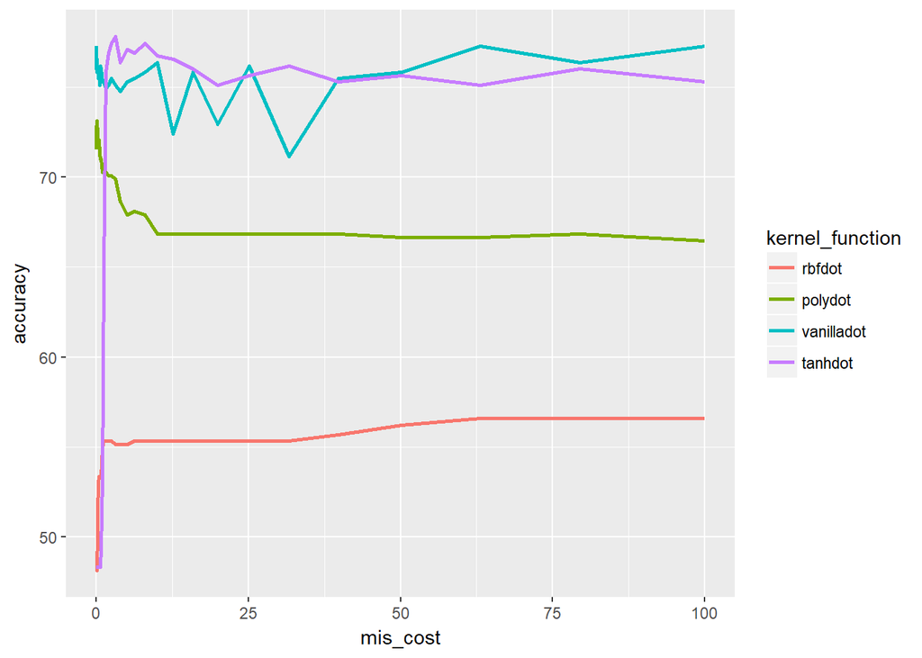

```r
library(readr)

results <- read_csv("results2.csv")
result_ggplot <- melt(results, id.vars = 'mis_cost')
colnames(result_ggplot)[2] <- 'kernel_function'
colnames(result_ggplot)[3] <- 'accuracy'

result_plot <- ggplot(result_ggplot) +
  geom_line(aes(x = mis_cost, y = accuracy, col = kernel_function), size = 1)

print(result_plot)
```

Based on the plot above I concluded that *vanilladot* and *tanhdot* has the best performance. The *vanilladot* has volatile performance, whereas the others for $C \geq 10$ have stable performance. The *rbfdot* and *tanhdot* perform poorly for lower $C$, nevertheless with increased $C$ they become much better. Especially the *tanhdot* function that gives the best performance of all functions used. The recommendation is then to use *tanhdot* kernel function and $C \approx 3.16$.

# Appendix

Here I provide the complete table of accuracies for used kernel functions and costs of misspecification.

```r
results %>% tbl_df %>% print(n = nrow(.))
```

```
## # A tibble: 41 x 5
##        mis_cost   rbfdot  polydot vanilladot  tanhdot
##           <dbl>    <dbl>    <dbl>      <dbl>    <dbl>
##  1   0.01000000 48.28829 71.53153   77.29730 48.28829
##  2   0.01258925 48.28829 71.89189   77.29730 48.28829
##  3   0.01584893 48.28829 71.71171   77.11712 48.28829
##  4   0.01995262 48.28829 71.71171   76.03604 48.28829
##  5   0.02511886 48.28829 72.07207   76.57658 48.28829
##  6   0.03162278 48.28829 72.43243   76.57658 48.28829
##  7   0.03981072 48.28829 72.61261   76.03604 48.28829
##  8   0.05011872 48.28829 73.15315   76.57658 48.28829
##  9   0.06309573 48.10811 72.43243   76.03604 48.28829
## 10   0.07943282 48.10811 72.25225   76.03604 48.28829
## 11   0.10000000 48.64865 72.97297   76.03604 48.28829
## 12   0.12589254 49.00901 72.97297   75.85586 48.28829
```

[output cut: 29 more lines]